# Wisdom in Crowd, What we have so far

Rong Guang

2022-10-24

```r
library(tidyverse)
library(tidyr)
library(gapminder) # dataset
library(finalfit)
library(broom)
library(gtsummary)#install.packages("gtsummary")
library(sjlabelled)#install.packages("sjlabelled")
library(lubridate)#install.packages("lubridate")
library(sjlabelled)
library(psych)
library(Hmisc)
library(expss)#install.packages("expss")
library(patchwork)
library(ggfortify)
library(DT)
library(modelsummary)#install.packages("modelsummary")
library(mice)
library(haven)
library(naniar)
library(DiagrammeR)#install.packages("DiagrammeR")
library(foreign)
```

# 1. Wrangling

## 1.1 loading data (the data set has been wranggled already)

```r
log <- read_sav("v1.2_merged_latest_mapped.sav") # raw data, numeric version
logF <- read.spss("v1.2_merged_latest_mapped.sav", use.value.label=TRUE, to.data.frame=TRUE)# raw data, factor version
```

## 1.2 Selecting variables

```r
#select potential variables for group analysis and consistency analysis
logpF <- logF %>%
  select(1:which(colnames(logF) == "aviprob_dm_7"), -starts_with("EMAIL"), -"email", -starts_with("LOCAT"), -starts_with("DISTR"),  -starts_with("LOG"), -starts_with("GPS"), -starts_with("IPAD"), -starts_with("AVI_E"), -starts_with("USER"), -ResponseId, starts_with("factor_detail"))
logp <- log %>%
  select(1:which(colnames(log) == "aviprob_dm_7"), -starts_with("EMAIL"), -"email", -starts_with("LOCAT"), -starts_with("DISTR"), -starts_with("LOG"), -starts_with("GPS"), -starts_with("IPAD"), -starts_with("AVI_E"), -starts_with("USER"), -ResponseId, starts_with("factor_detail"))
```

## 1.3 Generating codebook for selected variables

For efficiency, a searchable codebook is generated here.

```r
#pass variable and level labels into objects
var_book <- lapply(logp, function(x)var_lab(x))
val_book <- lapply(logp, function(x)get_labels(x))
val_book <- lapply(val_book, function(x)paste(x, collapse="<>"))

#unlist them
all_levels <- unlist(val_book) #convert list into vector
all_items <- unlist(var_book) #convert list into vector

#combine them to get a note book
codebook <- data.frame(all_items, all_levels) # generate a codebook which has variable label as a column and

#data set with two columns, one for variable label and one fore level labels. Searchable and Easy for reading.
datatable(codebook[-1,]) #
```

|  | all_items | all_levels |
| --- | --- | --- |
| filter_all_group | Group with all member's information being collected |  |
| route_djev_1_1 | What route on Djeveltanna did you ascend and descend? - East face Ascent | Ascent |
| route_djev_1_2 | What route on Djeveltanna did you ascend and descend? - East face Descent | Descent |
| route_djev_2_1 | What route on Djeveltanna did you ascend and descend? - West couloir Ascent | Ascent |
| route_djev_2_2 | What route on Djeveltanna did you ascend and descend? - West couloir Descent | Descent |
| route_djev_3_1 | What route on Djeveltanna did you ascend and descend? - Other Ascent | Ascent |
| route_djev_3_2 | What route on Djeveltanna did you ascend and descend? - Other Descent | Descent |
| skill_avi | How good are you at assessing and mitigating avalanche danger? Assessment of and mitigating avalanche danger involve evaluation and interpretation of snow, weather, and terrain. The six categories bel… | 1. Beginner&lt;&gt;2. Limited skills&lt;&gt;3. Basic skills&lt;&gt;4. Moderate to advanced skills&lt;&gt;5. Advanced skills&lt;&gt;6. Expert skills |
| skill_ski | How good are you at (non-motorized) backcountry riding? Please choose the category where you fulfil all the described skills (going up and down the mountain). If you do not fulfil all criterias please… | 1. Beginner&lt;&gt;2. Limited skills&lt;&gt;3. Basic skills&lt;&gt;4. Moderate to advanced skills&lt;&gt;5. Advanced skills&lt;&gt;6. Expert skills |
| skill_avi_3l | avi skill levels reduced to 3 |  |

[output cut: 192 more lines]

## 1.4 select cases

Groups (n = 55, skiers = 152) with all members information collected are selected. The final data sets for analysis are named after logpall (mostly numeric) and logall (mostly factor).

```r
logpall <- logp %>%
  filter(filter_full_group %in% c("1", "2")& filter_all_group == "1")
logall <- logpF %>%
 filter(filter_full_group %in% c("1", "2")& filter_all_group == "1")
```

## 1.5 relabel some old variables and generate new variables

```r
# Date variable get relabeled.
logall %>% select(Day) %>% datatable()
```

|  | Day |
| --- | --- |
| 1 | 26-Mar-22 |
| 2 | 26-Mar-22 |
| 3 | 26-Mar-22 |
| 4 | 26-Mar-22 |
| 5 | 27-Mar-22 |
| 6 | 27-Mar-22 |
| 7 | 27-Mar-22 |
| 8 | 28-Mar-22 |
| 9 | 27-Mar-22 |
| 10 | 27-Mar-22 |

[output cut: 142 more lines]

```r
logall <- logall %>%
  mutate(Day = Day %>%
           fct_recode("March 26th" ="\n26-Mar-22                                   ",
                      "April 3rd"="\n3-Apr-22                                    ",
                      "April 4th"="\n4-Apr-22                                    ",
                      "March 26th"="26-Mar-22                                    ",
                      "March 27th"="\n27-Mar-22                                   ",
                      "March 28th"="\n28-Mar-22                                   ",
                      "April 2nd"="\n2-Apr-22                                    ") %>%
                              factor())
logall$GN <- gsub(" ", "", logall$GN)
logall$GN <- as.factor(logall$GN)

# SOCIAL variables get relabeled.
logall <- logall %>%
  mutate(social_identification = soc_6_1 %>%
           fct_recode("1" = "Strongly disagree",
                      "2" = "Disagree",
                      "3" = "Neither agree nor disagree",
                      "4" = "Agree",
                      "5" = "Strongly agree",
                      NULL = "Don't know") %>%
           as.numeric() %>%
           ff_label("Iddentification score"))

logall <- logall %>%
  mutate(social_leadership = soc_6_2 %>%
           fct_recode("1" = "Strongly disagree",
                      "2" = "Disagree",
                      "3" = "Neither agree nor disagree",
                      "4" = "Agree",
                      "5" = "Strongly agree",
                      NULL = "Don't know") %>%
           as.numeric()%>%
           ff_label("Leadership score"))

logall <- logall %>%
  mutate(social_organization = soc_6_5 %>%
           fct_recode("1" = "Strongly disagree",
                      "2" = "Disagree",
                      "3" = "Neither agree nor disagree",
                      "4" = "Agree",
                      "5" = "Strongly agree",
                      NULL = "Don't know") %>%
           as.numeric()%>%
           ff_label("Rrganization score"))

logall <- logall %>%
  mutate(social_communication = soc_6_6 %>%
           fct_recode("1" = "Strongly disagree",
                      "2" = "Disagree",
                      "3" = "Neither agree nor disagree",
                      "4" = "Agree",
                      "5" = "Strongly agree",
                      NULL = "Don't know") %>%
           as.numeric()%>%
           ff_label("Communication score"))

logall <- logall %>%
  mutate(social_anomaly = soc_6_3 %>%
           fct_recode("5" = "Strongly disagree",
                      "4" = "Disagree",
                      "3" = "Neither agree nor disagree",
                      "2" = "Agree",
                      "1" = "Strongly agree",
                      NULL = "Don't know") %>%
           as.numeric()%>%
           ff_label("Anomaly score"))

logall <- logall %>%
  mutate(social_skill = soc_6_4 %>%
           fct_recode("5" = "Strongly disagree",
                      "4" = "Disagree",
                      "3" = "Neither agree nor disagree",
                      "2" = "Agree",
                      "1" = "Strongly agree",
                      NULL = "Don't know") %>%
           as.numeric())%>%
           ff_label("Skill score")

# SOCIAL totality is computed
logall <- logall %>%
  mutate(social_totality = rowSums(select(.,starts_with("social_")), na.rm = T) %>%
           ff_label("total social scores"))

#Within-group social totality mean is computed (take the average of the add-up of social scores across skiers from one group)
create_gp_soc_mean <- logall %>% group_by(GN) %>%
  summarise(group_social_mean = sum(social_totality)/n())
logall <- left_join(logall, create_gp_soc_mean, by = "GN")
median(logall$group_social_mean)
```

```
## [1] 29.42857
```

```r
##Within-group social totality mean is dichotomized.
logall <- logall %>%
  mutate(social_binary = case_when(group_social_mean > 29 ~ "high",
                                   group_social_mean <= 29 ~ "low") %>%
           ff_label("the with-in group social totality mean, high or low, cutoff=29"))
logpall <- logpall %>%
  mutate(social_binary = logall$social_binary %>%
           ff_label("the with-in group social totality mean, high or low, cutoff=29"))


#Cases A7 B13 modify Day of skiing to March 27th (their teammate finished it on 27th)
logall %>% select(Num,GN, Day) %>% filter (GN %in% c("A7", "B13"))
```

```
##   Num  GN        Day
## 1 119  A7 March 27th
## 2 122  A7 March 28th
## 3 110 B13 March 27th
## 4 120 B13 March 27th
## 5 123 B13 March 28th
```

```r
logall[logall$Num == "122", "Day"] <- "March 27th"
logall[logall$Num == "123", "Day"] <- "March 27th"
```

```r
#inspect the counts for each levels of identified avalanche problems.
logpall %>%
  select(starts_with("aviprob_exp")) %>% sapply(function(x)table(x)) #plan phase
```

```
##   aviprob_exp_10 aviprob_exp_1 aviprob_exp_2 aviprob_exp_3 aviprob_exp_4
## 0            149           147           146           110            96
## 1              3             5             6            42            56
##   aviprob_exp_5 aviprob_exp_6 aviprob_exp_7 aviprob_exp_8 aviprob_exp_9
## 0            42           107           140           140           138
## 1           110            45            12            12            14
```

```r
logpall %>%
  select(starts_with("aviprob_dm")) %>% sapply(function(x)table(x)) # trip phase
```

```
##   aviprob_dm_99 aviprob_dm_98 aviprob_dm_9 aviprob_dm_1 aviprob_dm_2
## 0            78            76           69           63           58
## 1             3             5           12           18           23
##   aviprob_dm_3 aviprob_dm_4 aviprob_dm_5 aviprob_dm_6 aviprob_dm_7
## 0           34           64           79           79           78
## 1           47           17            2            2            3
```

```r
# a new variable about the number of identified ava problems in plan phase is generated
logpall <- logpall %>%
  mutate(aviprob_exp_number = rowSums(select(., starts_with("aviprob_exp"), -starts_with("aviprob_exp_1")) == 1))

# a new variable about the number of identified ava problems in trip phase is generated
logpall <- logpall %>%
  mutate(aviprob_dm_number = rowSums(select(.,starts_with("aviprob_dm"), -starts_with("aviprob_dm_9")) == 1, na.rm = T))


###the above analyses were based on logpall (numeric). Pass them into logall (factor). Give them labels.
logall <- logall %>% mutate(aviprob_exp_number = logpall$aviprob_exp_number %>%
                              ff_label("number of ava problems during plan phase"))

logall <- logall %>% mutate(aviprob_dm_number = logpall$aviprob_dm_number %>%
                              ff_label("number of ava problems during trip phase"))
```

```r
#Number of factors that detail can be provided is generated/
logpall <- logpall %>%
  mutate(factor_detail_number = rowSums(select(., starts_with("factor_detail"), -factor_detail_4) == 1, na.rm = T))
logall <- logall %>% mutate(factor_detail_number = logpall$factor_detail_number %>%
                              ff_label("the number of factor details can be provided"))
```

```r
#group number dichotomized.
##create skier number
create_skier_number <- logall %>% group_by(GN) %>%
  summarise(skier_number = n())
logall <- left_join(logall, create_skier_number, by = "GN")
##dichotomized.
logall <- logall %>% mutate(group_number_size =
                              case_when(skier_number>2~"large",
                                        TRUE~ "small") %>%
                              ff_label("size of group large or small cutoff=2"))
logpall <- logpall %>% mutate(group_number_size = logall$group_number_size %>%
                                ff_label("size of group large or small cutoff=2"))
```

```r
#generate variables based on Martin's gold problems and gold non-problems
## gold for Day == "\n26-Mar-22"

logpall_2603 <- logpall %>% filter(Day %in% c("\n26-Mar-22", "26-Mar-22")| Num == "32") %>%
  mutate(number_gold_prob = 2 %>%
           ff_label("number for Martin's gold problems")) # number of gold problem

logpall_2603 <- logpall_2603 %>%
  mutate(number_gold_non_prob = 2 %>%
           ff_label("number for Martin's gold non-problems")) # number of gold non-problem

logpall_2603 <- logpall_2603 %>%
  mutate(skier_correct_number = rowSums(select(., c("aviprob_dm_3", "aviprob_dm_1")), na.rm = T) %>%
           ff_label("skier's correct identified ava problem against golden standard")) # number of skier's correct problem

logpall_2603 <- logpall_2603 %>%
  mutate(skier_incorrect_number = rowSums(select(., c("aviprob_dm_5", "aviprob_dm_6")), na.rm = T) %>%
           ff_label("skier's incorrect identified ava problem against golden standard"))# number of skier's incorrect problem

logpall_2603 <- logpall_2603 %>%
  mutate(skier_identified_number = aviprob_dm_number) # number of skier's incorrect problem
logpall_2603 <- logpall_2603 %>%
  mutate(skier_possible_number = skier_identified_number - skier_correct_number -skier_incorrect_number) # number of skier's possible problem
logpall_2603 %>% select(Num, starts_with("skier_")) #inspect
```

```
## # A tibble: 43 × 5
##      Num skier_correct_number skier_incorrect_number skier_identified_…¹ skier…²
##    <dbl>                <dbl>                  <dbl>               <dbl>   <dbl>
##  1    25                    1                      0                   1       0
##  2    36                    0                      0                   0       0
##  3    21                    0                      0                   0       0
##  4    32                    0                      0                   0       0
##  5    20                    0                      0                   0       0
##  6    31                    1                      0                   2       1
##  7    48                    0                      0                   0       0
##  8    52                    1                      0                   1       0
##  9    57                    0                      0                   1       1
## 10    59                    1                      0                   2       1
## # … with 33 more rows, and abbreviated variable names ¹skier_identified_number,
## #   ²skier_possible_number
```

```r
#generate variables based on Martin's gold problems and gold non-problems
#gold for Day == "\n27-Mar-22"
# for the meaning of each new variable, refer to the last chunk.
logpall_2703 <- logpall %>% filter(Day == "\n27-Mar-22") %>%
  mutate(number_gold_prob = 2 %>%
           ff_label("number for Martin's gold problems"))

logpall_2703 <- logpall_2703  %>%
  mutate(number_gold_non_prob = 2 %>%
           ff_label("number for Martin's gold non-problems"))

logpall_2703 <- logpall_2703  %>%
  mutate(skier_correct_number = rowSums(select(., c("aviprob_dm_3", "aviprob_dm_1")), na.rm = T) %>%
           ff_label("skier's correct identified ava problem against golden standard"))

logpall_2703 <- logpall_2703 %>%
  mutate(skier_incorrect_number = rowSums(select(., c("aviprob_dm_5", "aviprob_dm_6")), na.rm = T) %>%
           ff_label("skier's incorrect identified ava problem against golden standard"))

logpall_2703 <- logpall_2703 %>% mutate(skier_identified_number = aviprob_dm_number)
logpall_2703 <- logpall_2703 %>% mutate(skier_possible_number = skier_identified_number - skier_correct_number -skier_incorrect_number)
```

```r
#generate variables based on Martin's gold problems and gold non-problems
#gold for Day == "\n28-Mar-22", 2 problems no result
# for the meaning of each new variable, refer to the last chunk.
#routes with 2 ava problems
logpall_2803_2p <- logpall %>%
  filter(Day == "\n28-Mar-22" & (route_skit_2_1 == 1 | route_skit_2_2 == 1 | route_djev_2_1 == 1 | route_djev_2_2 ==1 | route_stor_2_1 == 1 | route_stor_2_2 == 1))# filter the routes with two problems


logpall_2803_2p <- logpall_2803_2p %>%
  mutate(number_gold_prob = 2 %>%
           ff_label("number for Martin's gold problems")) # number of gold problems

logpall_2803_2p <- logpall_2803_2p  %>%
  mutate(number_gold_non_prob = 2 %>%
           ff_label("number for Martin's gold non-problems"))# number of gold non-problem

logpall_2803_2p <- logpall_2803_2p  %>%
  mutate(skier_correct_number = rowSums(select(., c("aviprob_dm_3", "aviprob_dm_1")), na.rm = T) %>%
           ff_label("skier's correct identified ava problem against golden standard"))# number of skier's correctly identified problem

logpall_2803_2p <- logpall_2803_2p %>%
  mutate(skier_incorrect_number = rowSums(select(., c("aviprob_dm_5", "aviprob_dm_6")), na.rm = T) %>%
           ff_label("skier's incorrect identified ava problem against golden standard"))# number of skier's incorrectly identified problem

logpall_2803_2p <- logpall_2803_2p %>% mutate(skier_identified_number = aviprob_dm_number)# number of skier's identified problem
logpall_2803_2p <- logpall_2803_2p %>%
  mutate(skier_possible_number =
           skier_identified_number - skier_correct_number -skier_incorrect_number)# number of skier's correctly identified possible problems


#gold for Day == "\n28-Mar-22", 2 problems no result
#routes with 1 ava problems
# for the meaning of each new variable, refer to the last chunk.
logpall <- logpall %>% mutate(across(starts_with("route_"), ~replace(.,. == -99, NA)))
logpall_2803_1p <- logpall %>%
  filter(Day == "\n28-Mar-22" & is.na(route_skit_2_1)  & is.na(route_skit_2_2)  & is.na(route_djev_2_1) & is.na(route_djev_2_2)  & is.na(route_stor_2_1)  & is.na(route_stor_2_2))


logpall_2803_1p <- logpall_2803_1p %>%
  mutate(number_gold_prob = 1 %>%
           ff_label("number for Martin's gold problems"))

logpall_2803_1p <- logpall_2803_1p %>%
  mutate(number_gold_non_prob = 2 %>%
           ff_label("number for Martin's gold non-problems"))

logpall_2803_1p <- logpall_2803_1p  %>%
  mutate(skier_correct_number = rowSums(select(., c("aviprob_dm_3")), na.rm = T) %>%
           ff_label("skier's correct identified ava problem against golden standard"))

logpall_2803_1p <- logpall_2803_1p %>%
  mutate(skier_incorrect_number = rowSums(select(., c("aviprob_dm_5", "aviprob_dm_6")), na.rm = T) %>%
           ff_label("skier's correct identified ava problem against golden standard"))

logpall_2803_1p <- logpall_2803_1p %>% mutate(skier_identified_number = aviprob_dm_number)
logpall_2803_1p <- logpall_2803_1p %>% mutate(skier_possible_number =
                                                skier_identified_number - skier_correct_number -skier_incorrect_number)
logpall_2803_1p %>% select(starts_with("skier_"))
```

```
## # A tibble: 28 × 4
##    skier_correct_number skier_incorrect_number skier_identified_number skier_p…¹
##                   <dbl>                  <dbl>                   <dbl>     <dbl>
##  1                    0                      0                       0         0
##  2                    0                      0                       0         0
##  3                    0                      0                       0         0
##  4                    1                      0                       2         1
##  5                    0                      0                       0         0
##  6                    0                      0                       0         0
##  7                    0                      0                       0         0
##  8                    1                      0                       2         1
##  9                    0                      0                       0         0
## 10                    1                      0                       2         1
## # … with 18 more rows, and abbreviated variable name ¹skier_possible_number
```

```r
logpall_2803 <- rbind(logpall_2803_1p, logpall_2803_2p)
```

```r
#generate variables based on Martin's gold problems and gold non-problems
# gold for Day == "\n2-Apr-22"
# for the meaning of each new variable, refer to the last chunk.
logpall_0204 <- logpall %>% filter(Day == "\n2-Apr-22") %>%
  mutate(number_gold_prob = 3 %>%
           ff_label("number for Martin's gold problems"))

logpall_0204 <- logpall_0204  %>%
  mutate(number_gold_non_prob = 2 %>%
           ff_label("number for Martin's gold non-problems"))

logpall_0204 <- logpall_0204  %>%
  mutate(skier_correct_number = rowSums(select(., c("aviprob_dm_3", "aviprob_dm_1", "aviprob_dm_4")), na.rm = T) %>%
           ff_label("skier's correct identified ava problem against golden standard"))

logpall_0204 <- logpall_0204 %>%
  mutate(skier_incorrect_number = rowSums(select(., c("aviprob_dm_7", "aviprob_dm_6")), na.rm = T) %>%
           ff_label("skier's correct identified ava problem against golden standard"))

logpall_0204 <- logpall_0204 %>% mutate(skier_identified_number = aviprob_dm_number)
logpall_0204 <- logpall_0204 %>% mutate(skier_possible_number =
                                          skier_identified_number - skier_correct_number -skier_incorrect_number)
logpall_0204 %>% select(starts_with("skier_"))
```

```
## # A tibble: 18 × 4
##    skier_correct_number skier_incorrect_number skier_identified_number skier_p…¹
##                   <dbl>                  <dbl>                   <dbl>     <dbl>
##  1                    0                      0                       0         0
##  2                    0                      0                       0         0
##  3                    2                      0                       3         1
##  4                    0                      0                       0         0
##  5                    1                      0                       2         1
##  6                    0                      0                       0         0
##  7                    1                      0                       1         0
##  8                    1                      0                       2         1
##  9                    0                      0                       0         0
## 10                    2                      0                       2         0
## 11                    0                      0                       0         0
## 12                    0                      0                       0         0
## 13                    0                      0                       0         0
## 14                    2                      0                       2         0
## 15                    0                      0                       0         0
## 16                    1                      0                       1         0
## 17                    2                      0                       2         0
## 18                    0                      0                       0         0
## # … with abbreviated variable name ¹skier_possible_number
```

```r
#generate variables based on Martin's gold problems and gold non-problems
#gold for Day == "\n4-Apr-22", 2 problems no result
# for the meaning of each new variable, refer to the last chunk.
#routes with 2 ava problems
logpall_0404_2p <- logpall %>%
  filter(Day == "\n4-Apr-22" & (route_skit_2_1 == 1 | route_skit_2_2 == 1 | route_djev_2_1 == 1 | route_djev_2_2 ==1 | route_stor_2_1 == 1 | route_stor_2_2 == 1 | route_stor_4_1 ==1 | route_stor_4_1 == 1))
#no results


#gold for Day == "\n4-Apr-22"
#routes with 1 ava problems
# for the meaning of each new variable, refer to the last chunk.
logpall_0404_1p <- logpall %>%
  filter(Day == "\n4-Apr-22" & is.na(route_skit_2_1)  & is.na(route_skit_2_2)  & is.na(route_djev_2_1) & is.na(route_djev_2_2)  & is.na(route_stor_2_1)  & is.na(route_stor_2_2) & is.na(route_stor_4_1) & is.na(route_stor_4_1))


logpall_0404_1p <- logpall_0404_1p %>%
  mutate(number_gold_prob = 1 %>%
           ff_label("number for Martin's gold problems"))

logpall_0404_1p <- logpall_0404_1p %>%
  mutate(number_gold_non_prob = 3 %>%
           ff_label("number for Martin's gold non-problems"))

logpall_0404_1p <- logpall_0404_1p  %>%
  mutate(skier_correct_number = rowSums(select(., c("aviprob_dm_4")), na.rm = T) %>%
           ff_label("skier's correct identified ava problem against golden standard"))

logpall_0404_1p <- logpall_0404_1p %>%
  mutate(skier_incorrect_number =
           rowSums(select(., c("aviprob_dm_1", "aviprob_dm_2", "aviprob_dm_6")), na.rm = T) %>%
           ff_label("skier's correct identified ava problem against golden standard"))

logpall_0404_1p <- logpall_0404_1p %>% mutate(skier_identified_number = aviprob_dm_number)
logpall_0404 <- logpall_0404_1p %>% mutate(skier_possible_number = skier_identified_number - skier_correct_number -skier_incorrect_number)
```

```r
#combine the data sets above and pass them into logall
logpall_gold <- rbind(logpall_2603, logpall_2703, logpall_2803, logpall_0204, logpall_0404)
logpall_gold <- logpall_gold %>% select(Num, starts_with("skier_"), contains("_gold_"))
logall <- left_join(logall, logpall_gold, by = "Num")
```

```r
logall <- logall %>%
  mutate(TrueProbRate = skier_correct_number/number_gold_prob,  # generate Variable True Problem Rate
         FalseProbRate = skier_incorrect_number/number_gold_non_prob, # generate variable False Problem Rate
         Uncertainty = sqrt(1-(skier_identified_number/number_gold_prob)^2), # generate variable Uncertainty
         TrueConfidenceRate = TrueProbRate/Uncertainty, #generate variable True Confidence Rate
         UncertaintyP =
           sqrt(1-(skier_identified_number - skier_possible_number)/number_gold_prob)^2) # generate variable Uncertainty (updated version)
```

# 2. analysis

## 2.1 number of skiers in each group

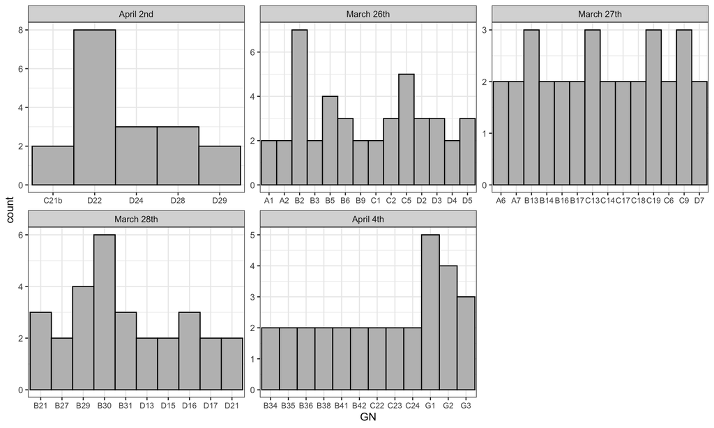

```r
#number of skiers in each group by day
logall %>%
  ggplot(aes(x = GN)) +
  geom_bar(width = 1, fill = "grey", color = "black") +
  facet_wrap(~Day, scales = "free") +
  theme_bw() +
  theme(axis.text.x = element_text(size = 8))
```

```r
#distribution of skiers in each group
groupsize <- logall %>% group_by(GN) %>%

  summarise(number = n())
groupsize$number <- as.factor(groupsize$number)
groupsizedist <- groupsize %>% group_by(number) %>%
  summarise(n = n())
groupsizedist
```

```
## # A tibble: 7 × 2
##   number     n
##   <fct>  <int>
## 1 2         32
## 2 3         15
## 3 4          3
## 4 5          2
## 5 6          1
## 6 7          1
## 7 8          1
```

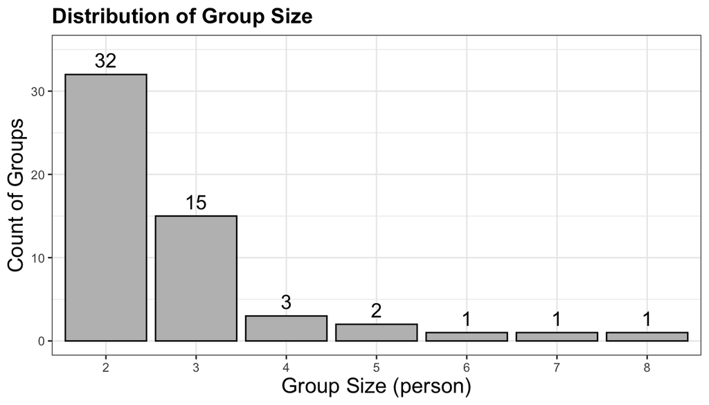

```r
groupsizedist %>% ggplot(aes(x= factor(number), y = n)) +
  geom_col(fill = "grey", color = "black")+
  labs(y = "Count of Groups", x = "Group Size (person)", title = "Distribution of Group Size") +
  geom_text(aes(label = n), size = 5, vjust = -0.5) +
  ylim(0, 35) +
  theme_bw() +
  theme (plot.title = element_text(size = 15, face = "bold"), axis.title = element_text(size = 15) )
```

```r
## The group size of each group by mountain triped over and date of trip
logall <- logall %>% mutate(mountain_1 = mountain_1 %>% fct_recode("Skittentind" = "Skittentind",
                                                                   "Djeveltanna" = "2",
                                                                   "Stortsteinnestind +8848" = "3"))
groupsize <- logall %>% group_by(GN) %>%
  summarise(Day = Day, ountain = mountain_1, number = n())
```

[output not shown]

```r
groupsize
```

```
## # A tibble: 152 × 4
## # Groups:   GN [55]
##    GN    Day        ountain     number
##    <fct> <fct>      <fct>        <int>
##  1 A1    March 26th Skittentind      2
##  2 A1    March 26th Skittentind      2
##  3 A2    March 26th Skittentind      2
##  4 A2    March 26th Skittentind      2
##  5 A6    March 27th Skittentind      2
##  6 A6    March 27th Skittentind      2
##  7 A7    March 27th Skittentind      2
##  8 A7    March 27th Skittentind      2
##  9 B13   March 27th Skittentind      3
## 10 B13   March 27th Skittentind      3
## # … with 142 more rows
```

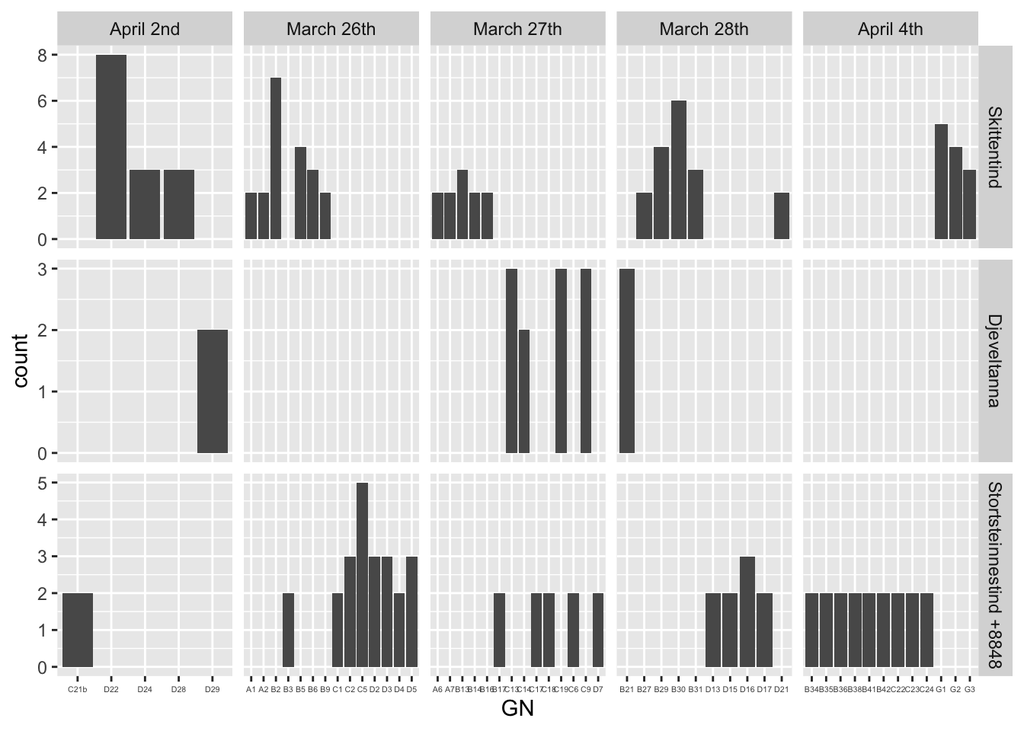

```r
groupsize %>% ggplot(aes(x=GN)) +
  geom_bar()+
  facet_grid(ountain~Day, scale ="free") +
  theme(axis.text.x =element_text(size = 4))
```

## 2.2 skills (ski and avalanche forecast skills)

### 2.2.1 distribution of skills within and across groups

```r
# heatmap for forecast skill within and across groups
library(janitor)#install.packages("janitor")
heatmap_forecast <- logall %>% group_by(GN) %>%
  mutate(MemeberID = row_number()) %>% ungroup()

heatmap_forecast <- heatmap_forecast %>% select(GN, MemeberID, skill_avi_numeric)

p1 <- ggplot(heatmap_forecast, aes(MemeberID, GN)) +
    geom_tile(aes(fill = skill_avi_numeric), colour = "black") +
    scale_fill_gradient(low = "white",high = "steelblue")+
  labs(y = "Group No.", x = "Group Member", title = "Forecast skill distribution within/across groups") +
  guides(fill=guide_legend(title="Forecast \nskill"))+ geom_text(aes(label = skill_avi_numeric), size = 3,
            vjust = 0.5, color = "black")+
 theme(axis.title = element_text(size = 18),
        plot.title = element_text(size = 20, face = "bold"))
```

```r
# heatmap for ski skill within and across groups
heatmap_ski <- logall %>% group_by(GN) %>%
  mutate(MemeberID = row_number()) %>% ungroup()

heatmap_ski <- heatmap_ski %>% select(GN, MemeberID, skill_ski_numeric)

p2 <- ggplot(heatmap_ski, aes(MemeberID, GN)) +
    geom_tile(aes(fill = skill_ski_numeric), colour = "black") +
    scale_fill_gradient(low = "white",high = "darkred")+
  labs(y = "Group No.", x = "Group Member",
       title = "Ski skill distribution within/across groups") +
  guides(fill=guide_legend(title="Ski \nskill"))+
  geom_text(aes(label = skill_ski_numeric), size = 3, vjust = 0.5, color = "black") +
  theme(axis.title = element_text(size = 18),
        plot.title = element_text(size = 20, face = "bold"))
```

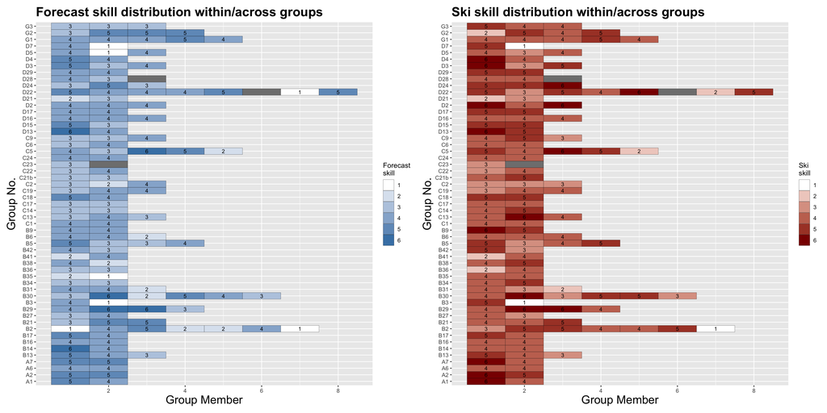

```r
p1+p2
```

### 2.2.2 trends of skills within case towards each other

```r
# trend group for forecast two types of skill towards each other
trend_a <- logall %>% select (No, skill_ski_numeric, skill_avi_numeric)
trend_b <- logall %>% count(skill_ski_numeric, skill_avi_numeric)
trend_graph <- full_join(trend_a, trend_b, by = c("skill_ski_numeric", "skill_avi_numeric"))

p3 <- trend_graph %>%
  pivot_longer(c(2,3), names_to = "skiORforecast", values_to = "level") %>%
  mutate(skiORforecast = skiORforecast %>% fct_recode("SkiSkill" ="skill_ski_numeric",
                                                      "ForecastSkill" = "skill_avi_numeric")) %>%
  ggplot(aes(x = skiORforecast, y = level, color =skiORforecast))+
  geom_line(aes(group = No,size = n), color = "black")+
  geom_point(shape = 19, size = 6) +
  theme(axis.text = element_text(size = 15),
        axis.title = element_text(size = 18),
        axis.title.x = element_blank(),
        plot.title = element_text(size = 18, face ="bold"), legend.position = "none") +
  labs(title = "Relation of ski and forecast skill for each individual")
```

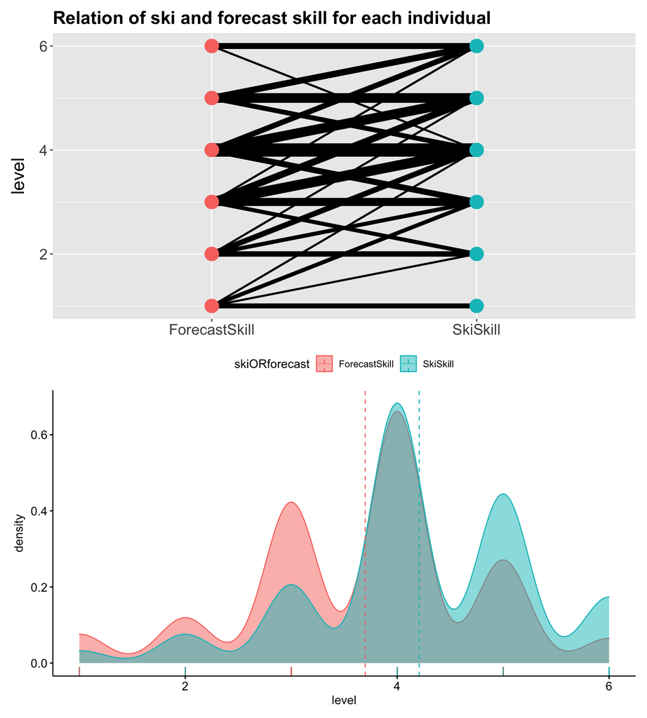

```r
# density graph for two types of skills
library(ggpubr)#install.packages("ggpubr")
p4 <- trend_graph %>% pivot_longer(c(2,3), names_to = "skiORforecast", values_to = "level") %>%
  ggplot(aes(x = level, fill = skiORforecast))+
  geom_histogram(binwidth = 1.2) +
  facet_wrap(~skiORforecast)
density_graph <-  trend_graph %>% select (2:3)%>%
  pivot_longer(everything(), names_to = "skiORforecast", values_to = "level") %>%
  mutate(skiORforecast = skiORforecast %>% fct_recode("SkiSkill" ="skill_ski_numeric",
                                                      "ForecastSkill" = "skill_avi_numeric"))
#above 8 lines are temporarily discarded
p5 <- ggdensity(density_graph, x = "level", color = "skiORforecast", add = "mean", rug = T, fill = "skiORforecast")
p3/p5
```

## 2.3 SOCIAL score distribution for each item

```r
#ridge graph for each SOCIAL item
library(ggridges)#install.packages("ggridges")

social_long <- logall %>% select(No, GN, starts_with("social")) %>%
  pivot_longer(c(3:8), names_to = "items", values_to = "scores")
p6.x <- ggdensity(social_long, x = "scores", color = "items", add = "mean", rug = T, fill = "items")
p6 <- social_long %>% ggplot(aes(x = scores, y = factor(items))) +
  geom_density_ridges(aes(fill = items)) +
  theme(legend.position = "bottom", axis.title.y = element_blank(),
        axis.text.y = element_blank())
```

```r
#barplot with dots for each SOCIAL item
p7 <- social_long %>% ggplot(aes(x=items, y= scores, color = items)) +
  geom_boxplot() +
  geom_jitter(size = 0.8, alpha = 0.5) +
  theme(legend.position = "none",
        axis.text.x = element_text(angle = 10, size = 12),
        axis.title =element_blank())
```

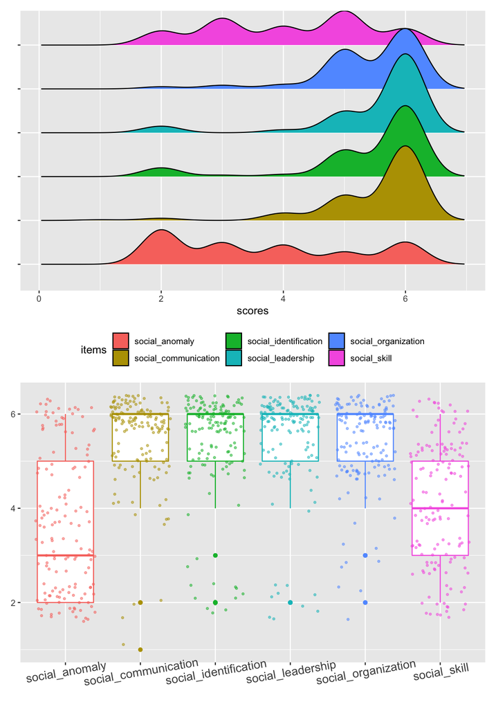

```r
p6/p7
```

### 2.4 Number of identified ava problems (plan vs trip phases)

```r
#Relation of number of identified ava problem \nplan and trip phase for each individual
trend_c <- logall %>% select (No, aviprob_exp_number, aviprob_dm_number)
trend_d <- logall %>% count(aviprob_exp_number, aviprob_dm_number)
trend_graph_prob <- full_join(trend_c, trend_d, by = c("aviprob_exp_number", "aviprob_dm_number"))

p8 <- trend_graph_prob %>%
  pivot_longer(c(2,3), names_to = "phase", values_to = "number") %>%
  mutate(phase = phase %>% fct_recode("PlanPhase" ="aviprob_exp_number",
                                                      "TripPhase" = "aviprob_dm_number")) %>%
  ggplot(aes(x = phase, y = number, color =phase))+
  geom_line(aes(group = No,size = n), color = "black")+
  geom_point(shape = 19, size = 6) +
  theme(axis.text = element_text(size = 15),
        axis.title = element_text(size = 18),
        axis.title.x = element_blank(),
        plot.title = element_text(size = 12, face ="bold"), legend.position = "none") +
  labs(title = "Relation of number of identified ava problem \nplan and trip phase for each individual",
       y = "Number of problems")
```

```r
#Relation of number of identified ava problems durig  plan and trip phases for expert forecaster
#expert forecasters
skill_3l <- logall %>% select(No, skill_avi_3l, skill_ski_3l)
trend_graph_prob_skill <- left_join(trend_graph_prob, skill_3l, by = "No")

p8.1 <- trend_graph_prob_skill %>% filter(skill_avi_3l == 3) %>%
  pivot_longer(c(2,3), names_to = "phase", values_to = "number") %>%
  mutate(phase = phase %>% fct_recode("PlanPhase" ="aviprob_exp_number",
                                                      "TripPhase" = "aviprob_dm_number")) %>%
  ggplot(aes(x = factor(phase, level = c("PlanPhase","TripPhase")), y = number, color =phase))+
  geom_line(aes(group = No,size = n), color = "black")+
  geom_point(shape = 19, size = 6) +
  theme(axis.text = element_text(size = 15),
        axis.title = element_text(size = 18),
        axis.title.x = element_blank(),
        plot.title = element_text(size = 10, face ="bold"), legend.position = "none") +
  labs(title = "Relation of number of identified ava problems durig \nplan and trip phases for expert forecaster",
       y = "Number of problems")
```

```r
#Relation of number of identified ava problems during plan and trip phases for expert skiers
#expert skiers
p8.2 <- trend_graph_prob_skill %>% filter(skill_ski_3l == 3) %>%
  pivot_longer(c(2,3), names_to = "phase", values_to = "number") %>%
  mutate(phase = phase %>% fct_recode("PlanPhase" ="aviprob_exp_number",
                                                      "TripPhase" = "aviprob_dm_number")) %>%
  ggplot(aes(x = factor(phase, level = c("PlanPhase","TripPhase")), y = number, color =phase))+
  geom_line(aes(group = No,size = n), color = "black")+
  geom_point(shape = 19, size = 6) +
  theme(axis.text = element_text(size = 15),
        axis.title = element_text(size = 18),
        axis.title.x = element_blank(),
        plot.title = element_text(size = 10, face ="bold"), legend.position = "none") +
  labs(title = "Relation of number of identified ava problems during \nplan and trip phases for expert skiers",
       y = "Number of problems")
```

```r
#Relation of number of identified ava problems during plan and trip phases for novice forecaster
#novice forecasters
p8.3 <- trend_graph_prob_skill %>% filter(skill_avi_3l == 1) %>%
  pivot_longer(c(2,3), names_to = "phase", values_to = "number") %>%
  mutate(phase = phase %>% fct_recode("PlanPhase" ="aviprob_exp_number",
                                                      "TripPhase" = "aviprob_dm_number")) %>%
  ggplot(aes(x = factor(phase, level = c("PlanPhase","TripPhase")), y = number, color =phase))+
  geom_line(aes(group = No,size = n), color = "black")+
  geom_point(shape = 19, size = 6) +
  theme(axis.text = element_text(size = 15),
        axis.title = element_text(size = 18),
        axis.title.x = element_blank(),
        plot.title = element_text(size = 10, face ="bold"), legend.position = "none") +
  labs(title = "Relation of number of identified ava problems during \nplan and trip phases for novice forecaster",
       y = "Number of problems")
```

```r
#elation of number of identified ava problems during plan and trip phases for novice skiers
#novice skiers
p8.4 <- trend_graph_prob_skill %>% filter(skill_ski_3l == 1) %>%
  pivot_longer(c(2,3), names_to = "phase", values_to = "number") %>%
  mutate(phase = phase %>% fct_recode("PlanPhase" ="aviprob_exp_number",
                                                      "TripPhase" = "aviprob_dm_number")) %>%
  ggplot(aes(x = factor(phase, level = c("PlanPhase","TripPhase")), y = number, color =phase))+
  geom_line(aes(group = No,size = n), color = "black")+
  geom_point(shape = 19, size = 6) +
  theme(axis.text = element_text(size = 15),
        axis.title = element_text(size = 18),
        axis.title.x = element_blank(),
        plot.title = element_text(size = 10, face ="bold"), legend.position = "none") +
  labs(title = "Relation of number of identified ava problems during \nplan and trip phases for novice skiers",
       y = "Number of problems")
```

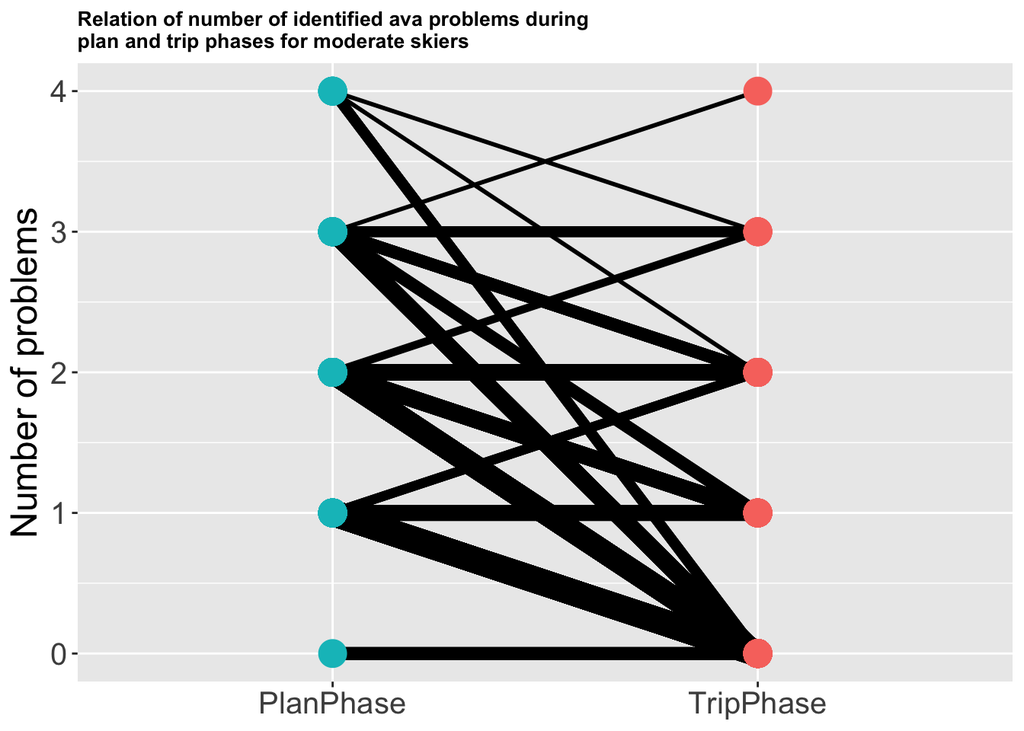

```r
#Relation of number of identified ava problems during plan and trip phases for moderate skiers
#moderate skiers
p8.5 <- trend_graph_prob_skill %>% filter(skill_avi_3l == 2) %>%
  pivot_longer(c(2,3), names_to = "phase", values_to = "number") %>%
  mutate(phase = phase %>% fct_recode("PlanPhase" ="aviprob_exp_number",
                                                      "TripPhase" = "aviprob_dm_number")) %>%
  ggplot(aes(x = factor(phase, level = c("PlanPhase","TripPhase")), y = number, color =phase))+
  geom_line(aes(group = No,size = n), color = "black")+
  geom_point(shape = 19, size = 6) +
  theme(axis.text = element_text(size = 15),
        axis.title = element_text(size = 18),
        axis.title.x = element_blank(),
        plot.title = element_text(size = 10, face ="bold"), legend.position = "none") +
  labs(title = "Relation of number of identified ava problems during \nplan and trip phases for moderate skiers",
       y = "Number of problems")

p8.5
```

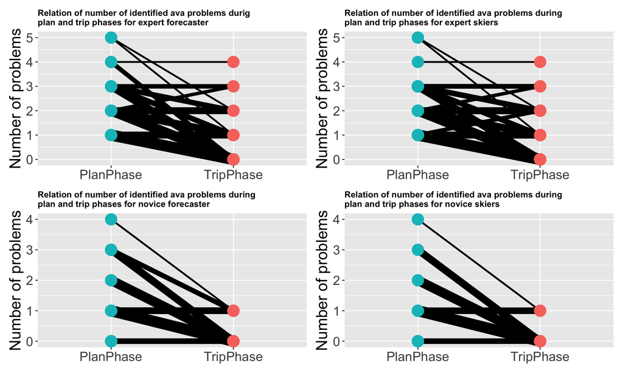

```r
p8.1/p8.3|p8.2/p8.4
```

## 2.5 Intra-case correlatiion (plan vs trip phases)

pFore each ava problem, kappa test is performed for expert and novice, separately. Finally, the kappa effect size for each ava problem will be added up to compare across phases.

```r
library(irr)#install.packages("irr")
#kappa
#new snow loose expert
kappa_prob_newsnowloose <- logpall %>% select(No, aviprob_exp_3, aviprob_dm_1, skill_avi_3l)
kappa1 <- kappa_prob_newsnowloose %>% filter(skill_avi_3l == 3) %>% select(2:3) %>% kappam.fleiss()
kappa1$value
```

```
## [1] 0.6041667
```

```r
#new snow loose novice
kappa1.5 <- kappa_prob_newsnowloose %>% filter(skill_avi_3l == 1) %>% select(2:3) %>% kappam.fleiss()
kappa1.5$value
```

```
## [1] -0.09090909
```

```r
#kappa
#new snow slab expert
kappa_prob_newsnowslab <- logpall %>% select(No, aviprob_exp_4, aviprob_dm_2, skill_avi_3l)
kappa2 <- kappa_prob_newsnowslab %>% filter(skill_avi_3l == 3) %>% select(2:3) %>% kappam.fleiss()
kappa2$value
```

```
## [1] 0.008695652
```

```r
#new snow slab novice
kappa2.5 <- kappa_prob_newsnowslab %>% filter(skill_avi_3l == 1) %>% select(2:3) %>% kappam.fleiss()
kappa2.5$value
```

```
## [1] 0.5555556
```

```r
#kappa
#wind drifted expert
kappa_prob_wind <- logpall %>% select(No, aviprob_exp_5, aviprob_dm_3, skill_avi_3l)
kappa3 <- kappa_prob_wind %>% filter(skill_avi_3l == 3) %>% select(2:3) %>% kappam.fleiss()
kappa3$value
```

```
## [1] 0.5632184
```

```r
#wind drifted novice
kappa3.5 <- kappa_prob_wind %>% filter(skill_avi_3l == 1) %>% select(2:3) %>% kappam.fleiss()
kappa3.5$value
```

```
## [1] 0.6571429
```

```r
#kappa
#persistent weak layer expert
kappa_prob_pwl <- logpall %>% select(No, aviprob_exp_6, aviprob_dm_4, skill_avi_3l)
kappa4 <- kappa_prob_pwl %>% filter(skill_avi_3l == 3) %>% select(2:3) %>% kappam.fleiss()
kappa4$value
```

```
## [1] 0.4153846
```

```r
#persistent weak layer novice
kappa4.5 <- kappa_prob_pwl %>% filter(skill_avi_3l == 1) %>% select(2:3) %>% kappam.fleiss()
kappa4.5$value
```

```
## [1] 0.5555556
```

```r
#kappa
#wet snow loose
kappa_prob_wetloose <- logpall %>% select(No, aviprob_exp_7, aviprob_dm_5, skill_avi_3l)
kappa5 <- kappa_prob_wetloose %>% filter(skill_avi_3l == 3) %>% select(2:3) %>% kappam.fleiss()
kappa5$value
```

```
## [1] -0.1515152
```

```r
#wet snow novice
kappa5.5 <- kappa_prob_wetloose %>% filter(skill_avi_3l == 1) %>% select(2:3) %>% kappam.fleiss()
kappa5.5$value
```

```
## [1] NaN
```

```r
#kappa
#wet snow slab expert
kappa_prob_wetslab <- logpall %>% select(No, aviprob_exp_8, aviprob_dm_6, skill_avi_3l)
kappa6 <- kappa_prob_wetslab %>% filter(skill_avi_3l == 3) %>% select(2:3) %>% kappam.fleiss()
kappa6$value
```

```
## [1] -0.08571429
```

```r
#wet snow slab novice
kappa6.5 <- kappa_prob_wetslab %>% filter(skill_avi_3l == 1) %>% select(2:3) %>% kappam.fleiss()
kappa6.5$value
```

```
## [1] NaN
```

```r
#kappa
#gliding snow expert
kappa_prob_wetslab <- logpall %>% select(No, aviprob_exp_9, aviprob_dm_7, skill_avi_3l)
kappa7 <- kappa_prob_wetslab %>% filter(skill_avi_3l == 3) %>% select(2:3) %>% kappam.fleiss()
kappa7$value
```

```
## [1] 0.3090909
```

```r
#gliding snow novice
kappa7.5 <- kappa_prob_wetslab %>% filter(skill_avi_3l == 1) %>% select(2:3) %>% kappam.fleiss()
kappa7.5$value
```

```
## [1] -0.09090909
```

```r
#calculate the root mean square of them
#experts' average consistency
sqrt(mean(kappa1$value^2, kappa2$value^2, kappa3$value^2, kappa4$value^2, kappa5$value^2, kappa6$value^2, kappa7$value^2))
```

```
## [1] 0.6041667
```

```r
#novice' average consistency
sqrt(mean(kappa1.5$value^2, kappa2.5$value^2, kappa3.5$value^2, kappa4.5$value^2, kappa5.5$value^2, kappa6.5$value^2, kappa7.5$value^2))
```

```
## [1] 0.09090909
```

## 2.6 avalanche factor analysis

Number of factors that details can be provided among expertise levels.

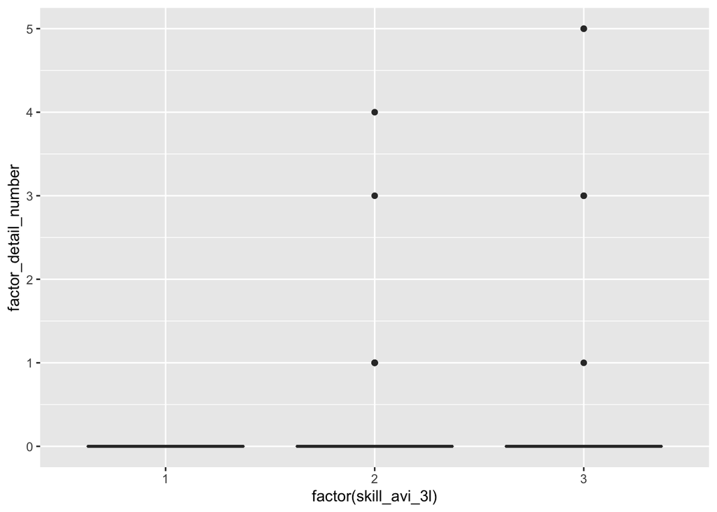

```r
logall %>% filter(!is.na(factor_detail_number)&!is.na(skill_avi_3l)) %>%
  ggplot(aes(x = factor(skill_avi_3l), y = factor_detail_number)) +
  geom_boxplot()
```

## 2.7 Intra-case correlatiion (small vs large group)

Fore each ava problem, kappa test is performed for small and large groups, separately. Finally, the kappa effect size for each ava problem will be added up to compare across size of groups

```r
library(irr)
#kappa
#new snow loose by large group
kappa_prob_newsnowloose <- logpall %>% select(No, aviprob_exp_3, aviprob_dm_1, group_number_size)
kappa1 <- kappa_prob_newsnowloose %>% filter(group_number_size == "large") %>%
  select(2:3) %>% kappam.fleiss()
kappa1$value
```

```
## [1] 0.507722
```

```r
#new snow loose by small group
kappa1.5 <- kappa_prob_newsnowloose %>% filter(group_number_size == "small")%>%
  select(2:3) %>% kappam.fleiss()
kappa1.5$value
```

```
## [1] 0.7333333
```

```r
#kappa
#new snow slab by large group
kappa_prob_newsnowslab <- logpall %>% select(No, aviprob_exp_4, aviprob_dm_2, group_number_size)
kappa2 <- kappa_prob_newsnowslab %>% filter(group_number_size == "large") %>% select(2:3) %>% kappam.fleiss()
kappa2$value
```

```
## [1] 0.4535714
```

```r
#new snow slab by small group
kappa2.5 <- kappa_prob_newsnowslab %>% filter(group_number_size == "small") %>% select(2:3) %>% kappam.fleiss()
kappa2.5$value
```

```
## [1] 0.2244418
```

```r
#kappa
#wind drifted  by large group
kappa_prob_wind <- logpall %>% select(No, aviprob_exp_5, aviprob_dm_3, group_number_size)
kappa3 <- kappa_prob_wind %>% filter(group_number_size == "large") %>% select(2:3) %>% kappam.fleiss()
kappa3$value
```

```
## [1] 0.4486486
```

```r
#wind drifted by small group
kappa3.5 <- kappa_prob_wind %>% filter(group_number_size == "small") %>% select(2:3) %>% kappam.fleiss()
kappa3.5$value
```

```
## [1] 0.4886364
```

```r
#kappa
#persistent weak layer by large group
kappa_prob_pwl <- logpall %>% select(No, aviprob_exp_6, aviprob_dm_4, group_number_size)
kappa4 <- kappa_prob_pwl %>% filter(group_number_size == "large") %>% select(2:3) %>% kappam.fleiss()
kappa4$value
```

```
## [1] 0.5663675
```

```r
#persistent weak layer by small group
kappa4.5 <- kappa_prob_pwl %>% filter(group_number_size == "small") %>% select(2:3) %>% kappam.fleiss()
kappa4.5$value
```

```
## [1] 0.4254446
```

```r
#kappa
#wet snow loose by large group
kappa_prob_wetloose <- logpall %>% select(No, aviprob_exp_7, aviprob_dm_5, group_number_size)
kappa5 <- kappa_prob_wetloose %>% filter(group_number_size == "large") %>% select(2:3) %>% kappam.fleiss()
kappa5$value
```

```
## [1] -0.07368421
```

```r
#wet snow by small group
kappa5.5 <- kappa_prob_wetloose %>% filter(group_number_size == "small") %>% select(2:3) %>% kappam.fleiss()
kappa5.5$value
```

```
## [1] 0.4642857
```

```r
#kappa
#wet snow slab by large group
kappa_prob_wetslab <- logpall %>% select(No, aviprob_exp_8, aviprob_dm_6, group_number_size)
kappa6 <- kappa_prob_wetslab %>% filter(group_number_size == "large") %>% select(2:3) %>% kappam.fleiss()
kappa6$value
```

```
## [1] 0.2330827
```

```r
#wet snow slab by small group
kappa6.5 <- kappa_prob_wetslab %>% filter(group_number_size == "small") %>% select(2:3) %>% kappam.fleiss()
kappa6.5$value
```

```
## [1] -0.05263158
```

```r
#kappa
#gliding snow by large group
kappa_prob_wetslab <- logpall %>% select(No, aviprob_exp_9, aviprob_dm_7, group_number_size)
kappa7 <- kappa_prob_wetslab %>% filter(group_number_size == "large") %>% select(2:3) %>% kappam.fleiss()
kappa7$value
```

```
## [1] 0.1861702
```

```r
#gliding snow by small group
kappa7.5 <- kappa_prob_wetslab %>% filter(group_number_size == "small") %>% select(2:3) %>% kappam.fleiss()
kappa7.5$value
```

```
## [1] 0.3454545
```

```r
#aggregate large group kapp effect size
sqrt(mean(kappa1$value^2, kappa2$value^2, kappa3$value^2, kappa4$value^2, kappa5$value^2, kappa6$value^2, kappa7$value^2))
```

```
## [1] 0.507722
```

```r
#aggregate small group kapp effect size
sqrt(mean(kappa1.5$value^2, kappa2.5$value^2, kappa3.5$value^2, kappa4.5$value^2, kappa5.5$value^2, kappa6.5$value^2, kappa7.5$value^2))
```

```
## [1] 0.7333333
```

## 2.8 Intra-case correlatiion (low vs high SOCIAL group)

Fore each ava problem, kappa test is performed for low and high social groups, separately. Finally, the kappa effect size for each ava problem will be added up to compare across these groups.

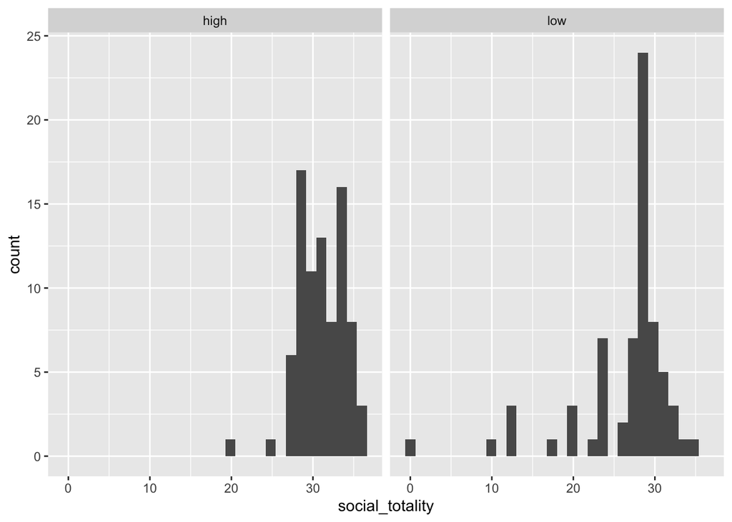

```r
#distribution of SOCIAL
logall %>% ggplot(aes(x = social_totality)) +
  geom_histogram() +
  facet_wrap(~social_binary)
```

```r
library(irr)
#kappa
#new snow loose by high SOCIAL group
kappa_prob_newsnowloose <- logpall %>% select(No, aviprob_exp_3, aviprob_dm_1, social_binary)
kappa1 <- kappa_prob_newsnowloose %>% filter(social_binary == "high") %>%
  select(2:3) %>% kappam.fleiss()
kappa1$value
```

```
## [1] 0.6425912
```

```r
#new snow loose by low SOCIAL group
kappa1.5 <- kappa_prob_newsnowloose %>% filter(social_binary == "low")%>%
  select(2:3) %>% kappam.fleiss()
kappa1.5$value
```

```
## [1] 0.4923077
```

```r
#kappa
#new snow slab by high SOCIAL group
kappa_prob_newsnowslab <- logpall %>% select(No, aviprob_exp_4, aviprob_dm_2, social_binary)
kappa2 <- kappa_prob_newsnowslab %>% filter(social_binary == "high") %>% select(2:3) %>% kappam.fleiss()
kappa2$value
```

```
## [1] 0.4535104
```

```r
#new snow slab by low SOCIAL group
kappa2.5 <- kappa_prob_newsnowslab %>% filter(social_binary == "low") %>% select(2:3) %>% kappam.fleiss()
kappa2.5$value
```

```
## [1] 0.231746
```

```r
#kappa
#wind drifted by high SOCIAL group
kappa_prob_wind <- logpall %>% select(No, aviprob_exp_5, aviprob_dm_3, social_binary)
kappa3 <- kappa_prob_wind %>% filter(social_binary == "high") %>% select(2:3) %>% kappam.fleiss()
kappa3$value
```

```
## [1] 0.4283097
```

```r
#wind drifted by low SOCIAL group
kappa3.5 <- kappa_prob_wind %>% filter(social_binary == "low") %>% select(2:3) %>% kappam.fleiss()
kappa3.5$value
```

```
## [1] 0.505
```

```r
#kappa
#persistent weak layer by high SOCIAL group
kappa_prob_pwl <- logpall %>% select(No, aviprob_exp_6, aviprob_dm_4, social_binary)
kappa4 <- kappa_prob_pwl %>% filter(social_binary == "high") %>% select(2:3) %>% kappam.fleiss()
kappa4$value
```

```
## [1] 0.5362319
```

```r
#persistent weak layer by low SOCIAL group
kappa4.5 <- kappa_prob_pwl %>% filter(social_binary == "low") %>% select(2:3) %>% kappam.fleiss()
kappa4.5$value
```

```
## [1] 0.4826428
```

```r
#kappa
#wet snow loose by high SOCIAL group
kappa_prob_wetloose <- logpall %>% select(No, aviprob_exp_7, aviprob_dm_5, social_binary)
kappa5 <- kappa_prob_wetloose %>% filter(social_binary == "high") %>% select(2:3) %>% kappam.fleiss()
kappa5$value
```

```
## [1] -0.05494505
```

```r
#wet snow novice by low SOCIAL group
kappa5.5 <- kappa_prob_wetloose %>% filter(social_binary == "low") %>% select(2:3) %>% kappam.fleiss()
kappa5.5$value
```

```
## [1] 0.2666667
```

```r
#kappa
#wet snow slab by high SOCIAL group
kappa_prob_wetslab <- logpall %>% select(No, aviprob_exp_8, aviprob_dm_6, social_binary)
kappa6 <- kappa_prob_wetslab %>% filter(social_binary == "high") %>% select(2:3) %>% kappam.fleiss()
kappa6$value
```

```
## [1] 0.1818182
```

```r
#wet snow slab by low SOCIAL group
kappa6.5 <- kappa_prob_wetslab %>% filter(social_binary == "low") %>% select(2:3) %>% kappam.fleiss()
kappa6.5$value
```

```
## [1] -0.03125
```

```r
#kappa
#gliding snow expert by high SOCIAL group
kappa_prob_wetslab <- logpall %>% select(No, aviprob_exp_9, aviprob_dm_7, social_binary)
kappa7 <- kappa_prob_wetslab %>% filter(social_binary == "high") %>% select(2:3) %>% kappam.fleiss()
kappa7$value
```

```
## [1] 0.1818182
```

```r
#gliding snow by low SOCIAL group
kappa7.5 <- kappa_prob_wetslab %>% filter(social_binary == "low") %>% select(2:3) %>% kappam.fleiss()
kappa7.5$value
```

```
## [1] 0.3508197
```

```r
#aggregate the kappa effect size for groups of either size, respectively
#high social
sqrt(mean(kappa1$value^2, kappa2$value^2, kappa3$value^2, kappa4$value^2, kappa5$value^2, kappa6$value^2, kappa7$value^2))
```

```
## [1] 0.6425912
```

```r
#low social
sqrt(mean(kappa1.5$value^2, kappa2.5$value^2, kappa3.5$value^2, kappa4.5$value^2, kappa5.5$value^2, kappa6.5$value^2, kappa7.5$value^2))
```

```
## [1] 0.4923077
```

## 2.9 Gold problem analysis

Gold problem indicators include True Condidence Rate, True Problem Rate, False Problem Rate, Uncertainy and Uncertainty(updated).

```r
#Gold problem indicators between expertise levels, group sizes and SOCIAL scores.
logall %>%
  summary_factorlist(dependent = "UncertaintyP",
                     explanatory = c("social_binary", "group_number_size", "skill_avi_3l"),

                     p = T) %>% datatable()
```

```
## Note: dependent includes missing data. These are dropped.
```

|  | label | levels | unit | value | p |
| --- | --- | --- | --- | --- | --- |
| 1 | the with-in group social totality mean, high or low, cutoff=29 | high | Mean (sd) | 0.8 (0.4) | 0.391 |
| 2 |  | low | Mean (sd) | 0.7 (0.4) |  |
| 3 | size of group large or small cutoff=2 | large | Mean (sd) | 0.7 (0.4) | 0.295 |
| 4 |  | small | Mean (sd) | 0.8 (0.3) |  |
| 5 | skill_avi_3l | 1 | Mean (sd) | 0.9 (0.2) | 0.061 |
| 6 |  | 2 | Mean (sd) | 0.7 (0.4) |  |
| 7 |  | 3 | Mean (sd) | 0.7 (0.4) |  |

```r
?summary_factorlist
```

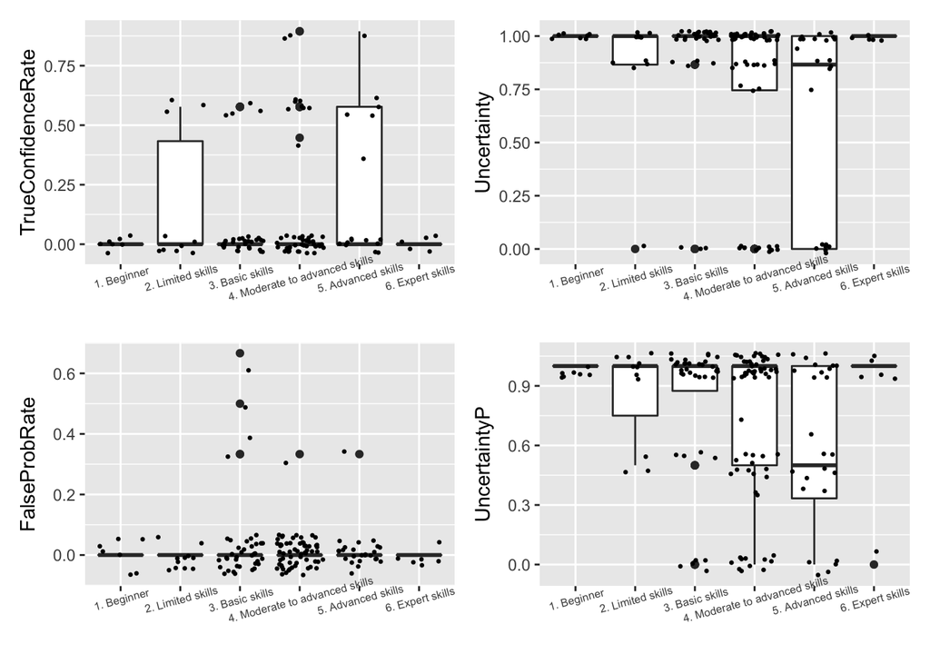

```r
#The distribution of each gold problem indicators
p21 <- logall %>% filter(!is.na(skill_avi)) %>% ggplot(aes(x = skill_avi, y = TrueConfidenceRate)) +
  geom_boxplot() +
  geom_jitter(size = 0.5)+
  theme(axis.text.x = element_text(angle = 15, size = 6), axis.title.x = element_blank())
p22<- logall %>% filter(!is.na(skill_avi)) %>% ggplot(aes(x = skill_avi, y = FalseProbRate)) +
  geom_boxplot() +
  geom_jitter(size = 0.5)+
  theme(axis.text.x = element_text(angle = 15, size = 6), axis.title.x = element_blank())
p23<- logall %>% filter(!is.na(skill_avi)) %>% ggplot(aes(x = skill_avi, y = Uncertainty)) +
  geom_boxplot() +
  geom_jitter(size = 0.5)+
  theme(axis.text.x = element_text(angle = 15, size = 6), axis.title.x = element_blank())

p24 <- logall %>% filter(!is.na(skill_avi)) %>% ggplot(aes(x = skill_avi, y = UncertaintyP)) +
  geom_boxplot() +
  geom_jitter(size = 0.5)+
  theme(axis.text.x = element_text(angle = 15, size = 6), axis.title.x = element_blank())

p21/p22|p23/p24
```

```r
#Modeling UcertaintyP
a <- logall %>%
  lm(UncertaintyP ~ skill_avi_numeric+social_totality+group_number_size, data = .)
a %>% summary()
```

```
##
## Call:
## lm(formula = UncertaintyP ~ skill_avi_numeric + social_totality +
##     group_number_size, data = .)
##
## Residuals:
##     Min      1Q  Median      3Q     Max
## -0.8173 -0.2448  0.1725  0.2722  0.4633
##
## Coefficients:
##                         Estimate Std. Error t value Pr(>|t|)
## (Intercept)             1.134267   0.215830   5.255 5.26e-07 ***
## skill_avi_numeric      -0.072511   0.027584  -2.629  0.00951 **
## social_totality        -0.005078   0.005984  -0.849  0.39752
## group_number_sizesmall  0.057989   0.061568   0.942  0.34785
## ---
## Signif. codes:  0 '***' 0.001 '**' 0.01 '*' 0.05 '.' 0.1 ' ' 1
##
## Residual standard error: 0.3682 on 143 degrees of freedom
##   (5 observations deleted due to missingness)
## Multiple R-squared:  0.05491,    Adjusted R-squared:  0.03508
## F-statistic: 2.769 on 3 and 143 DF,  p-value: 0.04391
```

```r
#Modeling UcertaintyP
a <- logall %>%
  lm(UncertaintyP ~ skill_avi_numeric+social_totality+group_number_size + sex + age + g_leader, data = .)
a %>% summary()
```

```
##
## Call:
## lm(formula = UncertaintyP ~ skill_avi_numeric + social_totality +
##     group_number_size + sex + age + g_leader, data = .)
##
## Residuals:
##      Min       1Q   Median       3Q      Max
## -0.89113 -0.18966  0.09556  0.15982  0.63262
##
## Coefficients:
##                         Estimate Std. Error t value Pr(>|t|)
## (Intercept)            -0.098117   1.957378  -0.050    0.961
## skill_avi_numeric       0.002634   0.196007   0.013    0.990
## social_totality         0.015813   0.065410   0.242    0.814
## group_number_sizesmall -0.061331   0.388350  -0.158    0.878
## sexMale                -0.048970   0.277638  -0.176    0.864
## age                     0.001992   0.005130   0.388    0.707
## g_leaderNo              0.490142   0.297511   1.647    0.134
##
## Residual standard error: 0.472 on 9 degrees of freedom
##   (136 observations deleted due to missingness)
## Multiple R-squared:  0.3317, Adjusted R-squared:  -0.1139
## F-statistic: 0.7444 on 6 and 9 DF,  p-value: 0.6285
```

```r
a <- logall %>%
  lm(skill_avi_numeric ~ sex+age+bc_years_4+ area_days, data=. )

a %>% summary()
```

```
##
## Call:
## lm(formula = skill_avi_numeric ~ sex + age + bc_years_4 + area_days,
##     data = .)
##
## Residuals:
##     Min      1Q  Median      3Q     Max
## -1.8241 -0.4456  0.0000  0.5070  1.6628
##
## Coefficients:
##                               Estimate Std. Error t value Pr(>|t|)
## (Intercept)                   2.532261   0.326655   7.752 4.48e-12 ***
## sexMale                       0.504598   0.157158   3.211  0.00173 **
## age                          -0.001605   0.002922  -0.549  0.58395
## bc_years_4skipped mv field   -2.383416   0.485476  -4.909 3.13e-06 ***
## bc_years_41                  -1.389432   0.435548  -3.190  0.00185 **
## bc_years_42                  -1.494085   0.355567  -4.202 5.34e-05 ***
## bc_years_43                  -0.432581   0.382589  -1.131  0.26061
## bc_years_44                  -0.544505   0.268519  -2.028  0.04495 *
## bc_years_45                  -0.415398   0.252250  -1.647  0.10241
## bc_years_46                   0.009027   0.822033   0.011  0.99126
## bc_years_47                  -0.252809   0.335507  -0.754  0.45272
## bc_years_48                  -0.064390   0.387871  -0.166  0.86845
## bc_years_49                  -0.363973   0.583580  -0.624  0.53410
## bc_years_410                 -0.068152   0.335440  -0.203  0.83937
## bc_years_411                  1.012564   0.591707   1.711  0.08980 .
## bc_years_412                  0.079857   0.423054   0.189  0.85062
## bc_years_414                 -0.241667   0.586926  -0.412  0.68131
## bc_years_415                 -0.120104   0.486295  -0.247  0.80538
## bc_years_416                 -1.585780   0.582997  -2.720  0.00757 **
## bc_years_417                 -0.324697   0.486572  -0.667  0.50594
## bc_years_418                  1.178970   0.586551   2.010  0.04683 *
## bc_years_419                 -1.482732   0.810486  -1.829  0.06999 .
## bc_years_420                  0.623872   0.314649   1.983  0.04984 *
## bc_years_422                  0.801327   0.827389   0.969  0.33488
## bc_years_425                  1.028285   0.820501   1.253  0.21273
## bc_years_426                  0.932071   0.584678   1.594  0.11372
## bc_years_430                  0.112144   0.329344   0.341  0.73411
## bc_years_435                  0.290309   0.819915   0.354  0.72395
## bc_years_436                 -0.698457   0.821336  -0.850  0.39692
## bc_years_437                  0.560598   0.812759   0.690  0.49178
## bc_years_440                  0.935885   0.586645   1.595  0.11346
## bc_years_446                  2.311172   0.822957   2.808  0.00588 **
## area_days2-4 days             0.754678   0.291547   2.589  0.01092 *
## area_daysUp to two weeks      0.964519   0.291534   3.308  0.00126 **
## area_daysMore than two weeks  1.495623   0.275092   5.437 3.21e-07 ***
## ---
## Signif. codes:  0 '***' 0.001 '**' 0.01 '*' 0.05 '.' 0.1 ' ' 1
##
## Residual standard error: 0.795 on 112 degrees of freedom
##   (5 observations deleted due to missingness)
## Multiple R-squared:  0.6085, Adjusted R-squared:  0.4897
## F-statistic:  5.12 on 34 and 112 DF,  p-value: 2.755e-11
```